# Station #5110

Bryan Blanc

August 12, 2015

This is a summary of the times, lane numbers, and flag types that have have been flagged for supsect values at this PORTAL station. This document is dynamic and can be regenerated.

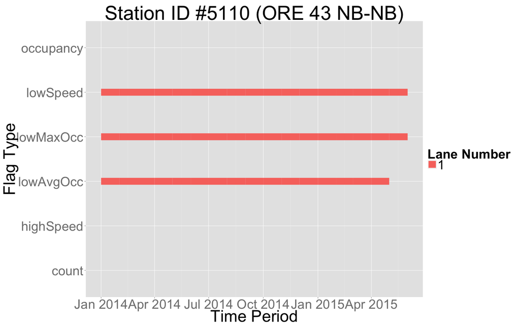

# Data Quality Flags

- Outage Period: 2015-05-01 to 2015-06-01
  - Dectector: 1788 (Lane # 1 )
    - Flags: lowSpeed, lowMaxOcc
- Outage Period: 2015-04-01 to 2015-05-01
  - Dectector: 1788 (Lane # 1 )
    - Flags: lowSpeed, lowMaxOcc, lowAvgOcc
- Outage Period: 2015-03-01 to 2015-04-01
  - Dectector: 1788 (Lane # 1 )
    - Flags: lowSpeed, lowMaxOcc, lowAvgOcc
- Outage Period: 2015-02-01 to 2015-03-01
  - Dectector: 1788 (Lane # 1 )
    - Flags: lowSpeed, lowMaxOcc, lowAvgOcc
- Outage Period: 2015-01-01 to 2015-02-01
  - Dectector: 1788 (Lane # 1 )
    - Flags: lowSpeed, lowMaxOcc, lowAvgOcc
- Outage Period: 2014-12-01 to 2015-01-01
  - Dectector: 1788 (Lane # 1 )
    - Flags: lowSpeed, lowMaxOcc, lowAvgOcc
- Outage Period: 2014-11-01 to 2014-12-01
  - Dectector: 1788 (Lane # 1 )
    - Flags: lowSpeed, lowMaxOcc, lowAvgOcc
- Outage Period: 2014-10-01 to 2014-11-01
  - Dectector: 1788 (Lane # 1 )
    - Flags: lowSpeed, lowMaxOcc, lowAvgOcc
- Outage Period: 2014-09-01 to 2014-10-01
  - Dectector: 1788 (Lane # 1 )
    - Flags: lowSpeed, lowMaxOcc, lowAvgOcc
- Outage Period: 2014-08-01 to 2014-09-01
  - Dectector: 1788 (Lane # 1 )
    - Flags: lowSpeed, lowMaxOcc, lowAvgOcc
- Outage Period: 2014-07-01 to 2014-08-01
  - Dectector: 1788 (Lane # 1 )
    - Flags: lowSpeed, lowMaxOcc, lowAvgOcc
- Outage Period: 2014-06-01 to 2014-07-01
  - Dectector: 1788 (Lane # 1 )
    - Flags: lowSpeed, lowMaxOcc, lowAvgOcc
- Outage Period: 2014-05-01 to 2014-06-01
  - Dectector: 1788 (Lane # 1 )
    - Flags: lowSpeed, lowMaxOcc, lowAvgOcc
- Outage Period: 2014-04-01 to 2014-05-01
  - Dectector: 1788 (Lane # 1 )
    - Flags: lowSpeed, lowMaxOcc, lowAvgOcc
- Outage Period: 2014-03-01 to 2014-04-01
  - Dectector: 1788 (Lane # 1 )
    - Flags: lowSpeed, lowMaxOcc, lowAvgOcc
- Outage Period: 2014-02-01 to 2014-03-01
  - Dectector: 1788 (Lane # 1 )
    - Flags: lowSpeed, lowMaxOcc, lowAvgOcc
- Outage Period: 2014-01-01 to 2014-02-01
  - Dectector: 1788 (Lane # 1 )
    - Flags: lowSpeed, lowMaxOcc, lowAvgOcc